# Act-Learn Analysis

Kyle MacDonald

This script analyzes data from an experiment testing the effectiveness of active, passive, and pedagogical training in a category learning task.

```r
rm(list=ls())
knitr::opts_chunk$set(warning=FALSE, message=FALSE, sanitize = T,
                      fig.height=6, fig.width=9, echo=F, cache = T)
```

## Exclusionary criteria

Overall performance (averaged across blocks) was more than three standard deviations below the mean of their group.

Map means and sd to variables

Flag subject means that are +/- 3sd

```
## Source: local data frame [4 x 4]
## Groups: condition, include [?]
##
##   condition include           category_type   n()
##       (chr)   (chr)                   (chr) (int)
## 1    active include information-integration    27
## 2    active include              rule-based    67
## 3 receptive include information-integration    29
## 4 receptive include              rule-based    25
```

## Descriptives

| condition | category_type | mean_exp_length | order | count |
| --- | --- | --- | --- | --- |
| active | information-integration | 10.571768 | order1 | 14 |
| active | information-integration | 10.571768 | order2 | 13 |
| active | rule-based | 8.545480 | order1 | 62 |
| active | rule-based | 8.545480 | order2 | 5 |
| receptive | information-integration | 3.268057 | order1 | 12 |
| receptive | information-integration | 3.268057 | order2 | 17 |
| receptive | rule-based | 3.186861 | order1 | 18 |
| receptive | rule-based | 3.186861 | order2 | 7 |

## Descriptives

Histogram of length of experiment split by condition

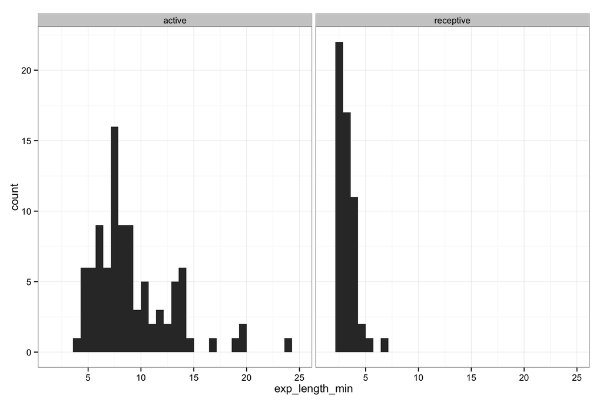

```
## Source: local data frame [2 x 2]
##
##   condition mean(exp_length_min)
##       (chr)                (dbl)
## 1    active             9.127499
## 2 receptive             3.230466
```

## Overall accuracy analysis

Get mean accuracy for each condition and category type

Plot.

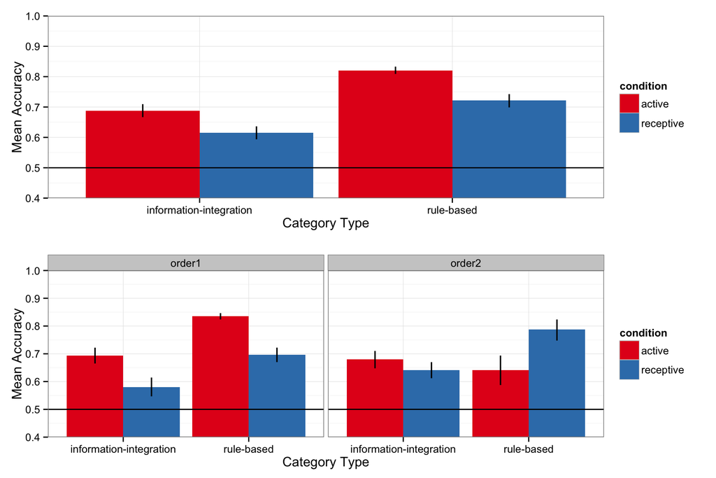

## Accuracy by block analysis

Plot accuracy over blocks

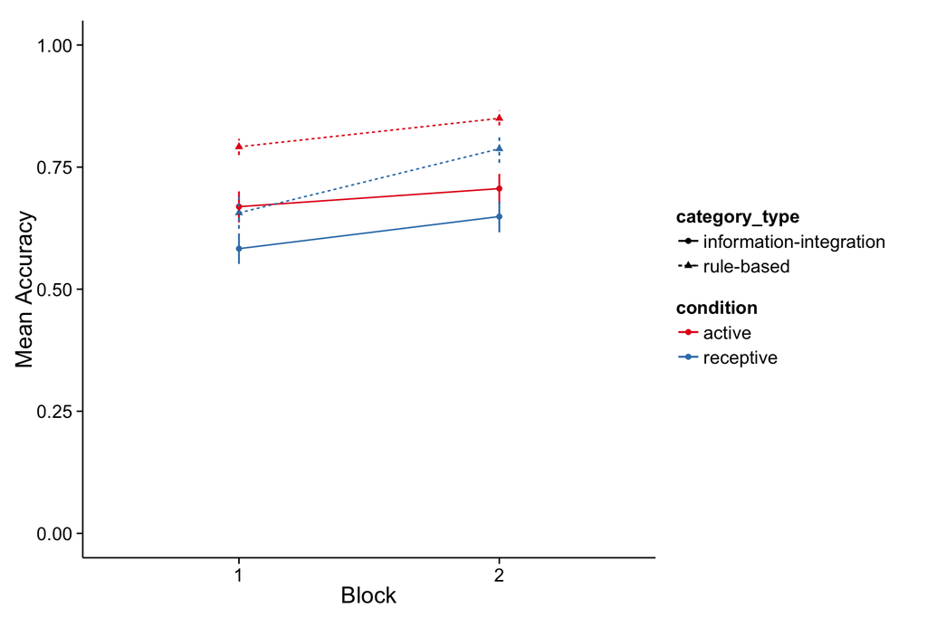

Accuracy by block and dimension.

Plot accuracy over blocks

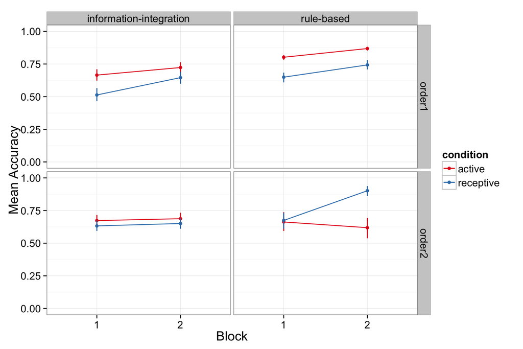

## Evidence selection analysis (active learning)

Analyze the average distance of participants’ samples from the optimal decision boundary.

Rotate, so orientation and radius are on the same dimension.

- dim of interest = dimension with category boundary
- other dim = dimesnion that does not contain the category boundary

Transform information-integration samples

## Plot group level sampling behavior.

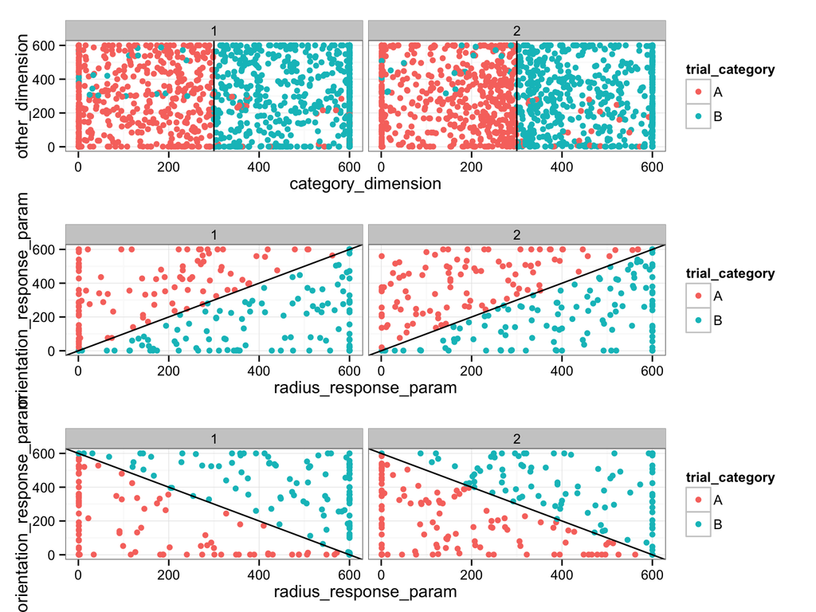

## Plot individual participant sampling behavior

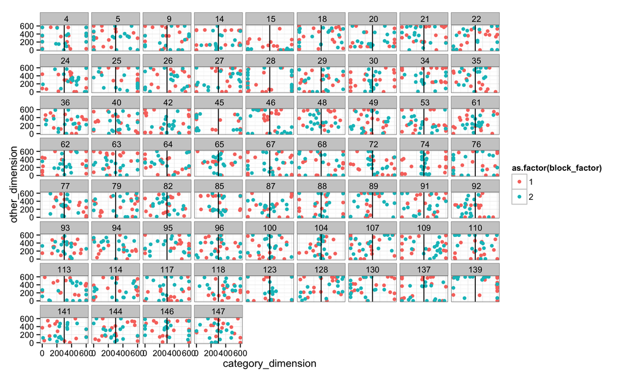

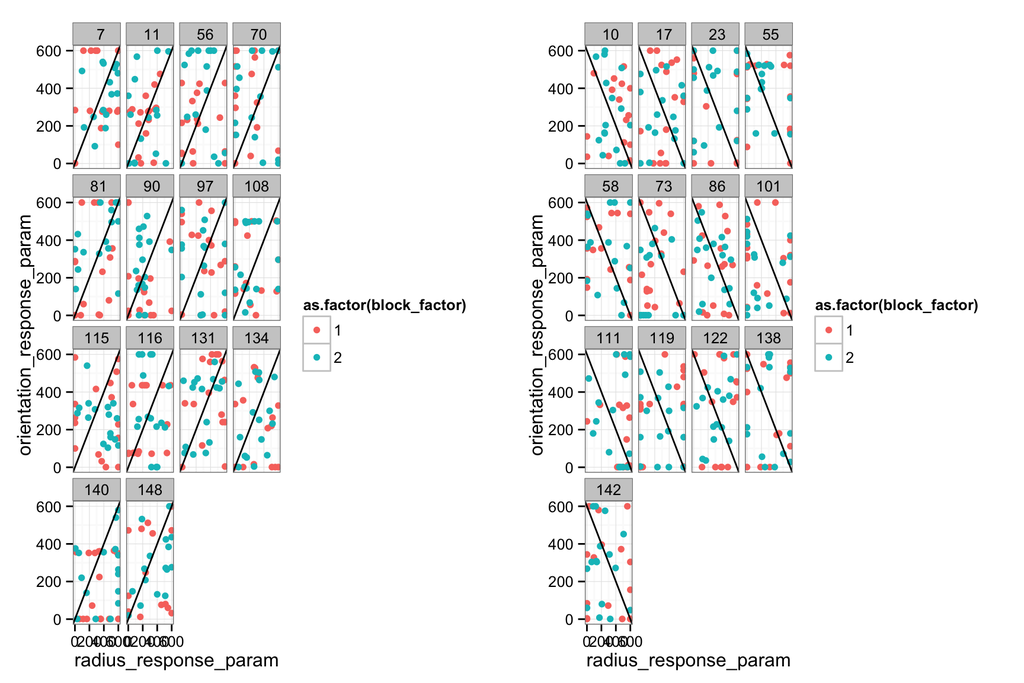

Get distance from optimal decision boundary for each sample.

Now get the average distance across subjects

Now plot.

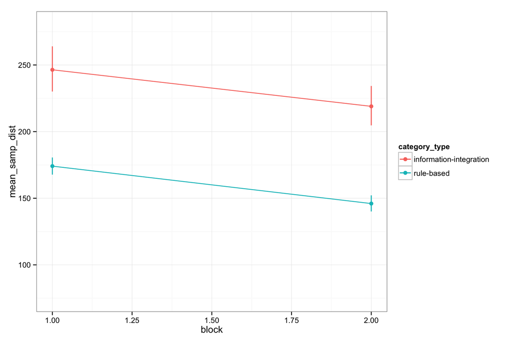

Compute average response times across blocks for the two different dimensions.

Now plot.

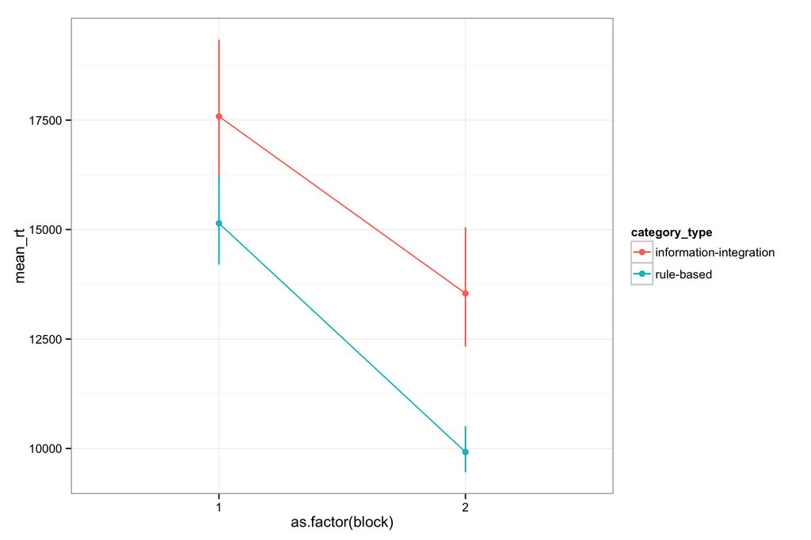

## Plot distribution of test trials

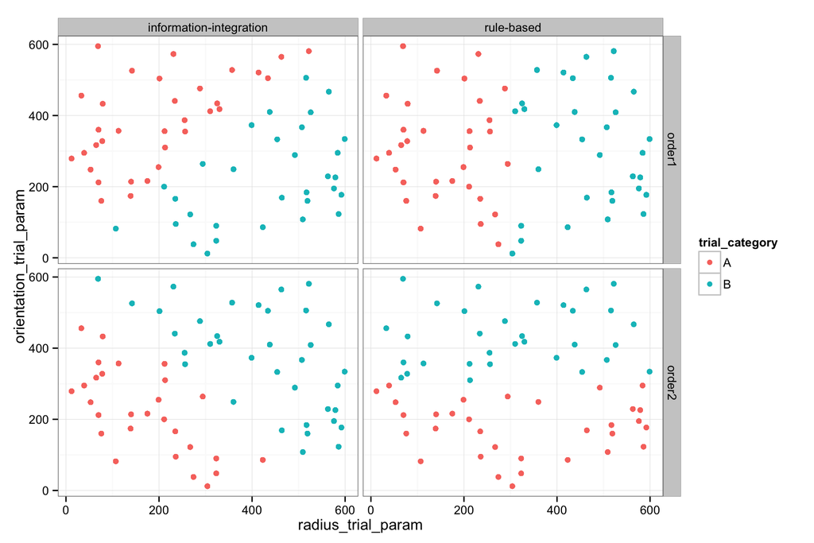

## Relationship between sampling and test

Sample distance and accuracy

Plot

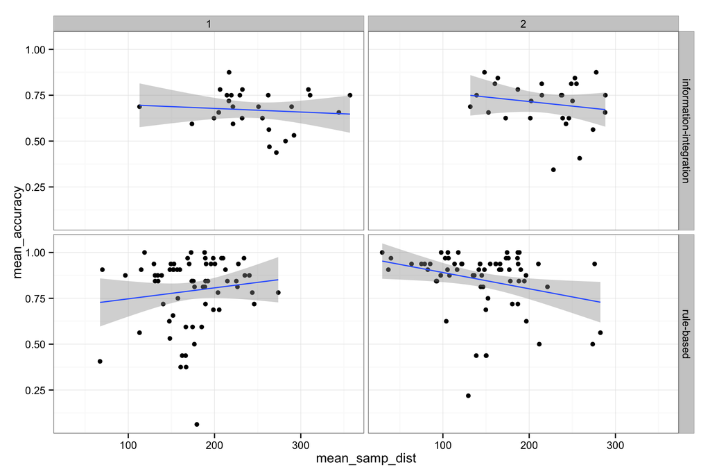

## Histogram mean accuracy

By block

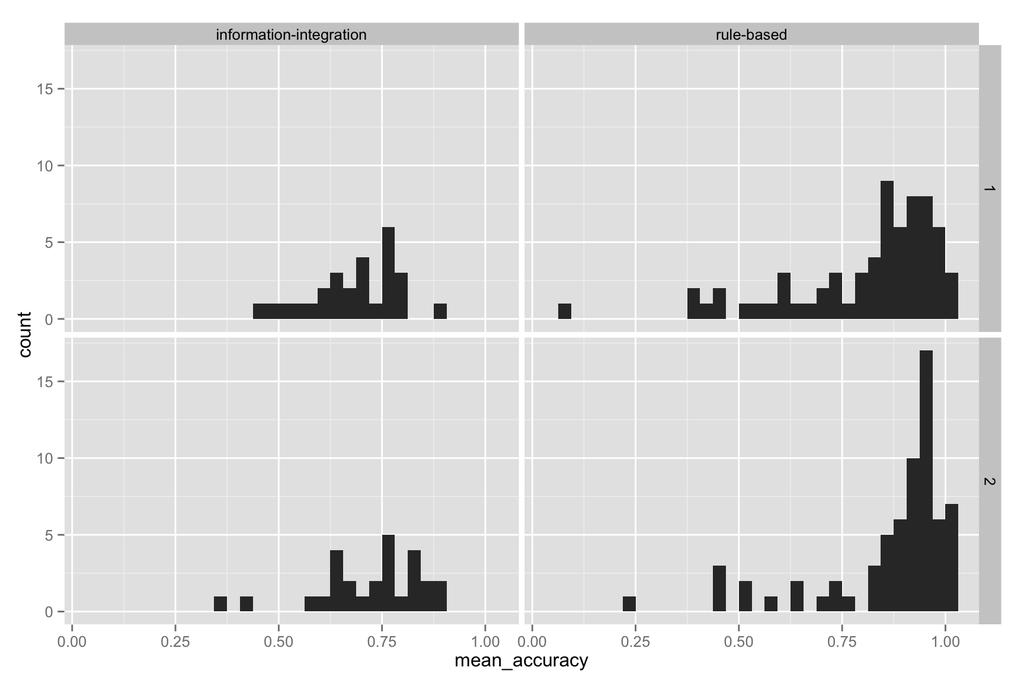

Collapsed

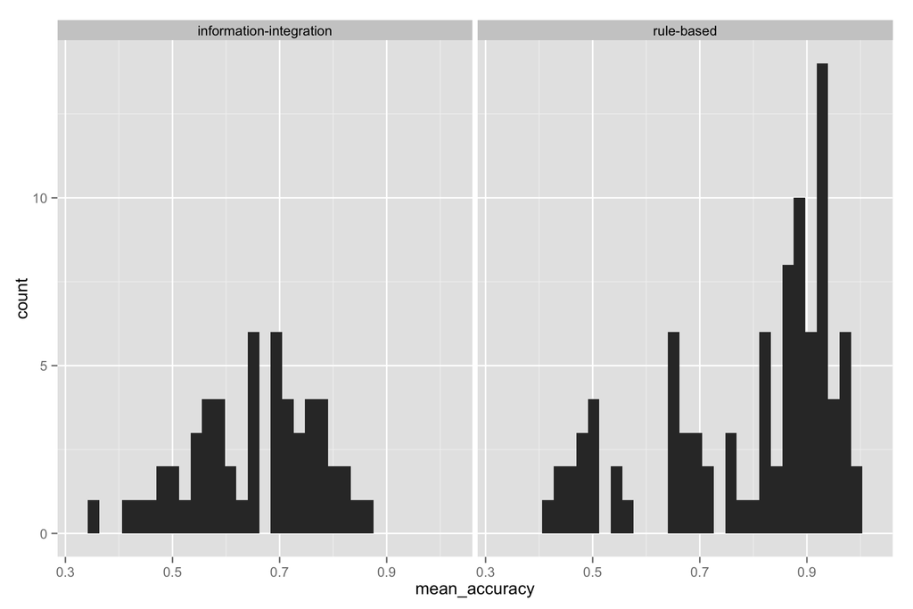

## LMERs

Model the relationship between mean sampling distance on training trials and mean accuracy on test trials.

```
##
## Call:
## lm(formula = mean_accuracy ~ mean_samp_dist * block, data = ss_all)
##
## Residuals:
##      Min       1Q   Median       3Q      Max
## -0.70045 -0.07919  0.04043  0.10583  0.25387
##
## Coefficients:
##                        Estimate Std. Error t value Pr(>|t|)
## (Intercept)           0.6806326  0.1372327   4.960  1.6e-06 ***
## mean_samp_dist        0.0002848  0.0006919   0.412   0.6811
## block                 0.1596691  0.0814367   1.961   0.0514 .
## mean_samp_dist:block -0.0007157  0.0004252  -1.683   0.0940 .
## ---
## Signif. codes:  0 '***' 0.001 '**' 0.01 '*' 0.05 '.' 0.1 ' ' 1
##
## Residual standard error: 0.1664 on 184 degrees of freedom
## Multiple R-squared:  0.1096, Adjusted R-squared:  0.09505
## F-statistic: 7.547 on 3 and 184 DF,  p-value: 8.655e-05
```

Negative relationship such that those subjects who sampled farther away from the boundary were less accurate on test, but only in the second active learning block.

Next, we try to predict correct based on condition

```
## Generalized linear mixed model fit by maximum likelihood (Laplace
##   Approximation) [glmerMod]
##  Family: binomial  ( logit )
## Formula: correct ~ condition * category_type + (1 | subids)
##    Data: filter(df, trial_type == "test")
##
##      AIC      BIC   logLik deviance df.resid
##   9918.7   9954.5  -4954.3   9908.7     9467
##
## Scaled residuals:
##     Min      1Q  Median      3Q     Max
## -4.5285 -0.9001  0.3620  0.6291  1.3064
##
## Random effects:
##  Groups Name        Variance Std.Dev.
##  subids (Intercept) 0.634    0.7962
## Number of obs: 9472, groups:  subids, 148
##
## Fixed effects:
##                                            Estimate Std. Error z value
## (Intercept)                                  0.8327     0.1625   5.126
## conditionreceptive                          -0.3242     0.2252  -1.440
## category_typerule-based                      0.9355     0.1953   4.790
## conditionreceptive:category_typerule-based  -0.2943     0.3032  -0.971
##                                            Pr(>|z|)
## (Intercept)                                2.97e-07 ***
## conditionreceptive                            0.150
## category_typerule-based                    1.66e-06 ***
## conditionreceptive:category_typerule-based    0.332
## ---
## Signif. codes:  0 '***' 0.001 '**' 0.01 '*' 0.05 '.' 0.1 ' ' 1
##
## Correlation of Fixed Effects:
##             (Intr) cndtnr ctgr_-
## condtnrcptv -0.721
## ctgry_typr- -0.832  0.600
## cndtnrcp:_-  0.536 -0.743 -0.643
```

Effect coding (condition vs. category type) to test main effects.

Model with effect coding.

```
## Generalized linear mixed model fit by maximum likelihood (Laplace
##   Approximation) [glmerMod]
##  Family: binomial  ( logit )
## Formula: correct ~ condition_factor * category_type_factor + (1 | subids)
##    Data: filter(df, trial_type == "test")
##
##      AIC      BIC   logLik deviance df.resid
##   9918.7   9954.5  -4954.3   9908.7     9467
##
## Scaled residuals:
##     Min      1Q  Median      3Q     Max
## -4.5285 -0.9001  0.3620  0.6291  1.3064
##
## Random effects:
##  Groups Name        Variance Std.Dev.
##  subids (Intercept) 0.634    0.7962
## Number of obs: 9472, groups:  subids, 148
##
## Fixed effects:
##                                                          Estimate
## (Intercept)                                               1.06485
## condition_factorbase=passive                              0.23566
## category_type_factorbase=rb                              -0.39418
## condition_factorbase=passive:category_type_factorbase=rb -0.07357
##                                                          Std. Error
## (Intercept)                                                 0.07600
## condition_factorbase=passive                                0.07580
## category_type_factorbase=rb                                 0.07593
## condition_factorbase=passive:category_type_factorbase=rb    0.07580
##                                                          z value Pr(>|z|)
## (Intercept)                                               14.011  < 2e-16
## condition_factorbase=passive                               3.109  0.00188
## category_type_factorbase=rb                               -5.192 2.08e-07
## condition_factorbase=passive:category_type_factorbase=rb  -0.971  0.33177
##
## (Intercept)                                              ***
## condition_factorbase=passive                             **
## category_type_factorbase=rb                              ***
## condition_factorbase=passive:category_type_factorbase=rb
## ---
## Signif. codes:  0 '***' 0.001 '**' 0.01 '*' 0.05 '.' 0.1 ' ' 1
##
## Correlation of Fixed Effects:
##             (Intr) cndt_= ctg__=
## cndtn_fctr= -0.172
## ctgry_typ_=  0.098  0.217
## cndtn_=:__=  0.216  0.103 -0.172
```

Intercept is the mean of the means (or the grand mean) of all the groups. These data are unbalanced. Active better than passive. Information integration worse than rule-based.